# PRV - 4 cell lines: TSS dynamics

Balázs Kakuk

# Project info

Samples: dcDNA Seq  
pychopper: no  
mapping version: v6  
LoRTIA: yes (stranded only output)

Filtering samples:  
- C6_2h_3  
- PC-12_8h_3  
- C6_0.5h_1  
- C6_0.5h_2  
- C6_0.5h_3  
- PC-12_0.5h_3  
- PK-15_2h3

Normalization: Viral read count

## Only those reads were counted, where LoRTIA found *5-prime* adapter sequences !

```
## C6_2h_3  was filtered out!
## PC-12_8h_3  was filtered out!
## C6_0.5h_1  was filtered out!
## C6_0.5h_2  was filtered out!
## PC-12_0.5h_3  was filtered out!
```

# 1. Counts based on TSS only (5` -ends of reads)

## Statistics of counts

```
## character(0)
```

### Difference from mean

### Varcoeff

## Clustering of PK-15 Samples

```
## Filtering genes with very low counts:
## UL53
## UL52
## UL24
## NOIR
## US3
## US6
```

```
## Bootstrap (r = 0.49)... Done.
## Bootstrap (r = 0.59)... Done.
## Bootstrap (r = 0.69)... Done.
## Bootstrap (r = 0.79)... Done.
## Bootstrap (r = 0.89)... Done.
## Bootstrap (r = 1.0)... Done.
## Bootstrap (r = 1.1)... Done.
## Bootstrap (r = 1.2)... Done.
## Bootstrap (r = 1.3)... Done.
## Bootstrap (r = 1.39)... Done.
```

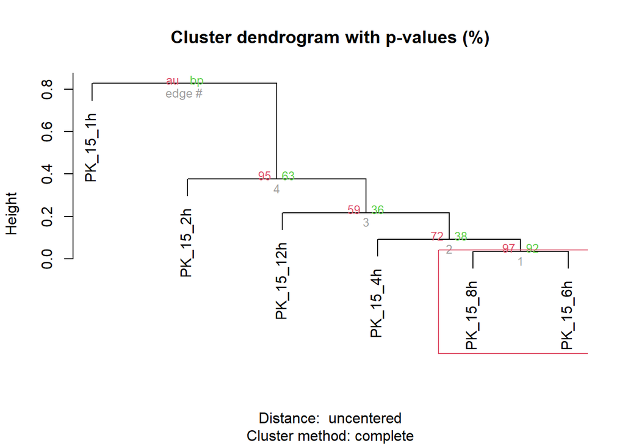

## Clustering of genes into de-novo clusters using hierarchial clustering based on PK-15

### Cluster memberships

```
## Bootstrap (r = 0.5)... Done.
```

```
## Bootstrap (r = 0.67)... Done.
```

```
## Bootstrap (r = 0.83)... Done.
```

```
## Bootstrap (r = 1.0)... Done.
```

```
## Bootstrap (r = 1.17)... Done.
```

```
## Bootstrap (r = 1.33)... Done.
```

### Optimal number of clusters

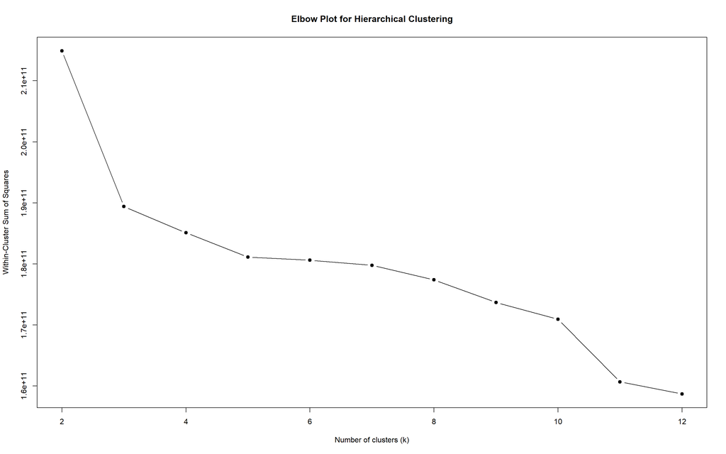

### Finding the optimal number of clusters to cut the tree at and calculate

#### Clustering statistics: Cluster number: 5

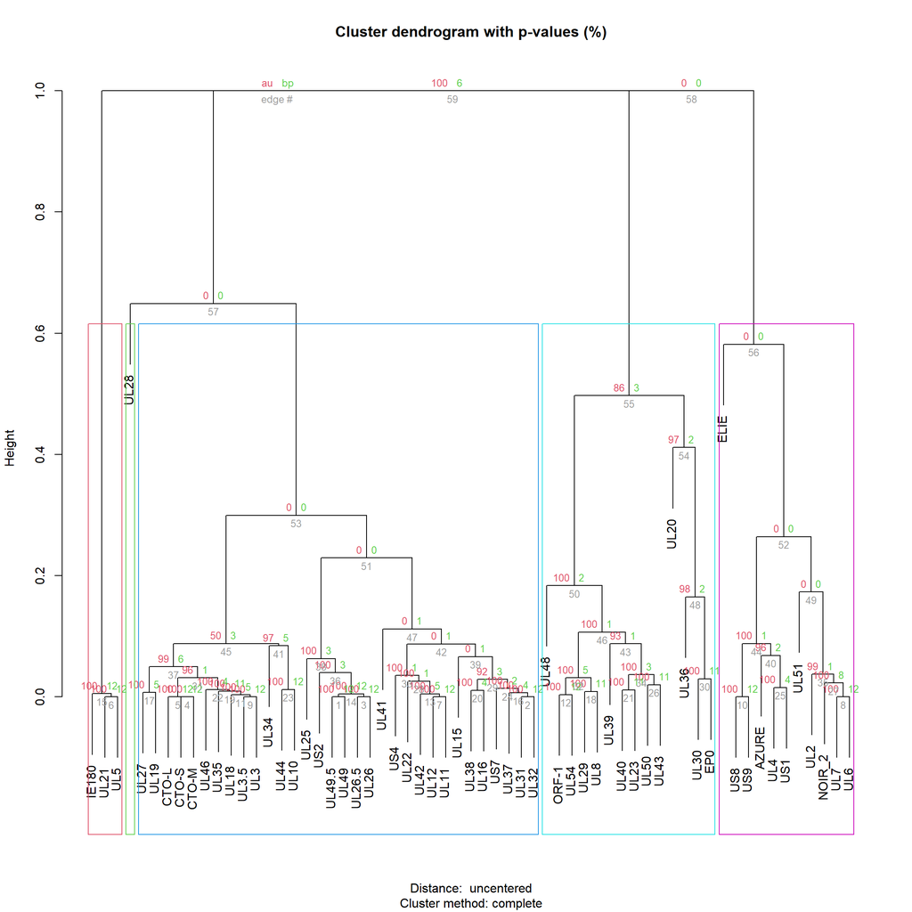

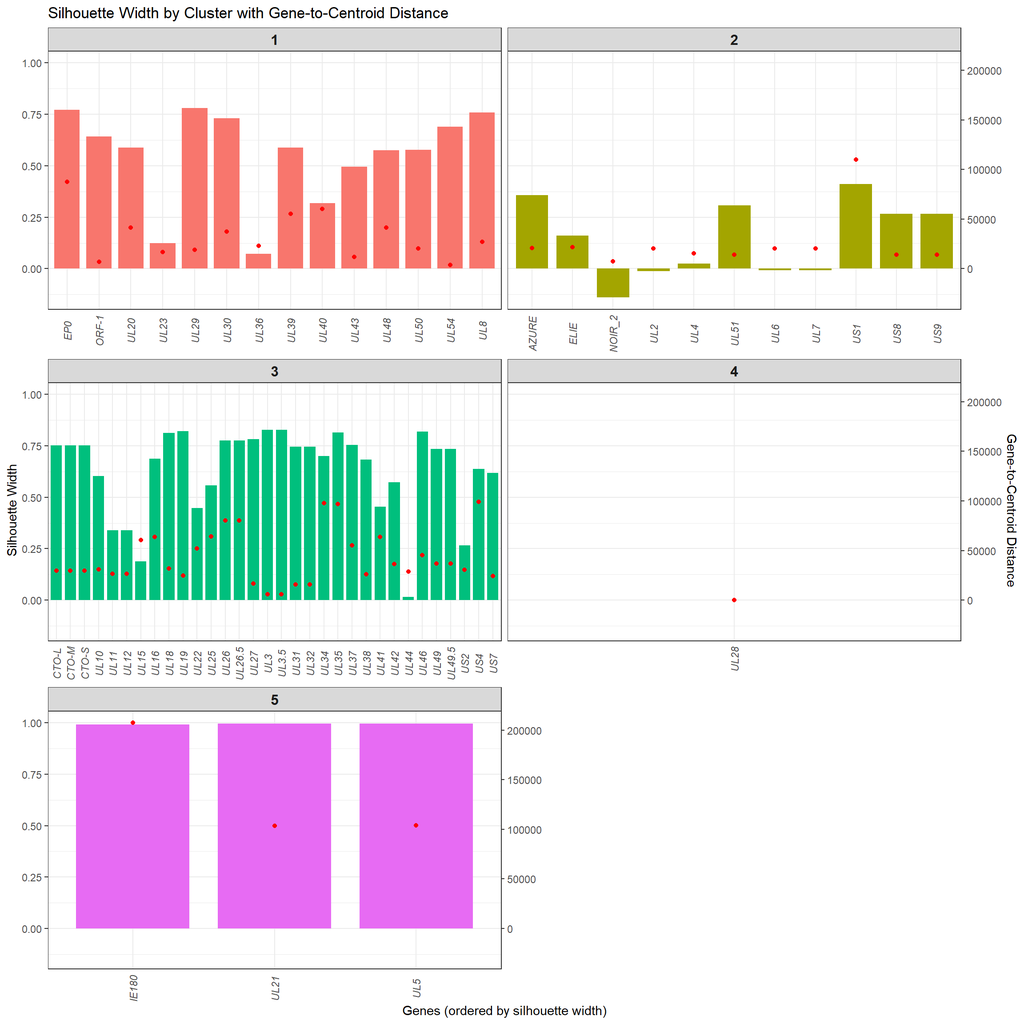

```
## Unclustered Genes, based on a Silhouette threshold of 0 and a Scaled Distance of 20:
## UL7
## UL6
## UL2
## NOIR_2
```

```
## Unclustered Genes, based on AU threshold of 0.95:
```

#### Clustering statistics: Cluster number: 6

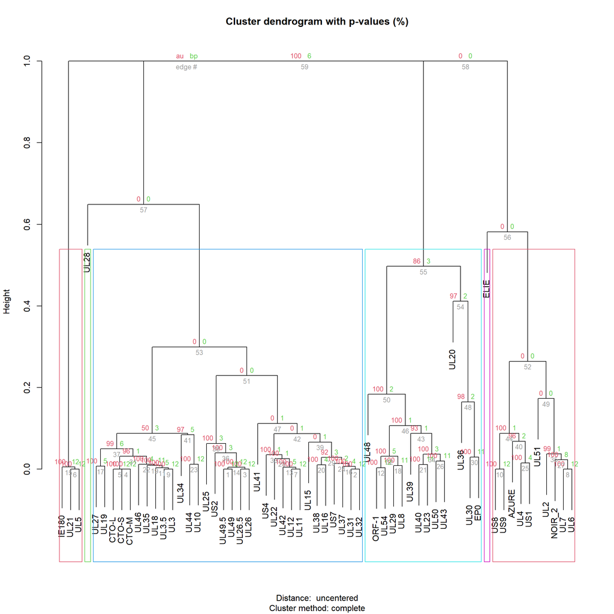

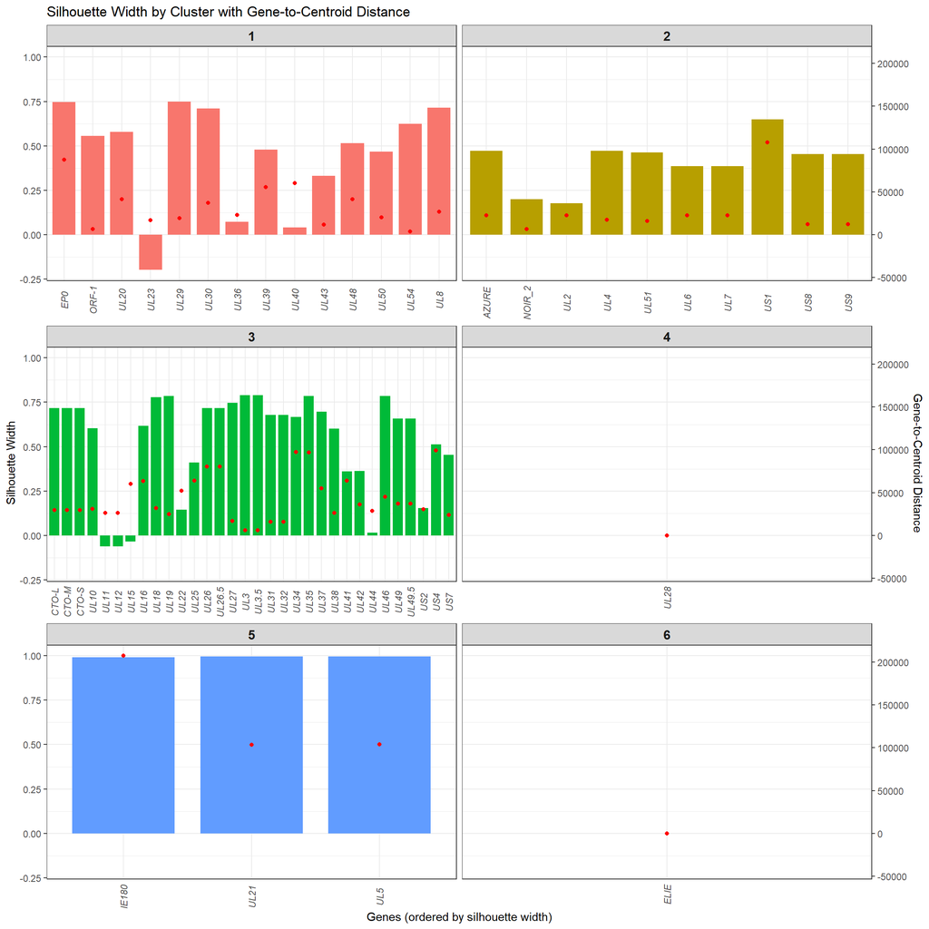

```
## Unclustered Genes, based on a Silhouette threshold of 0 and a Scaled Distance of 20:
## UL23
## UL15
## UL12
## UL11
```

```
## Unclustered Genes, based on AU threshold of 0.95:
```

#### Clustering statistics: Cluster number: 7

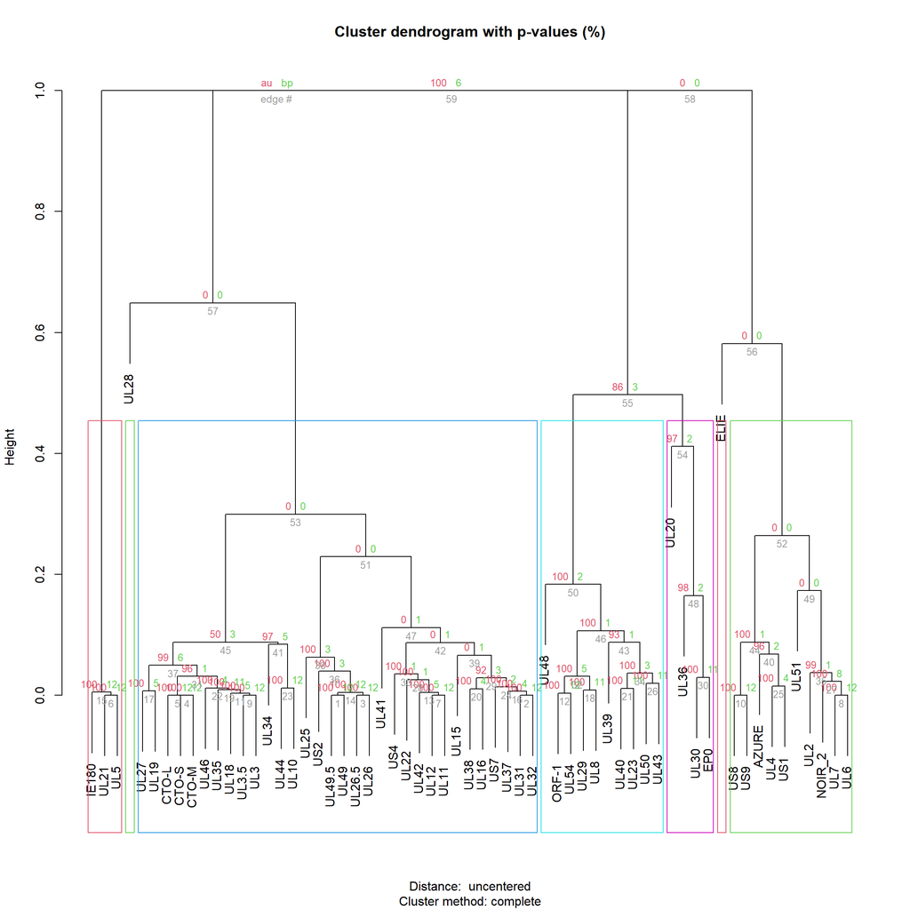

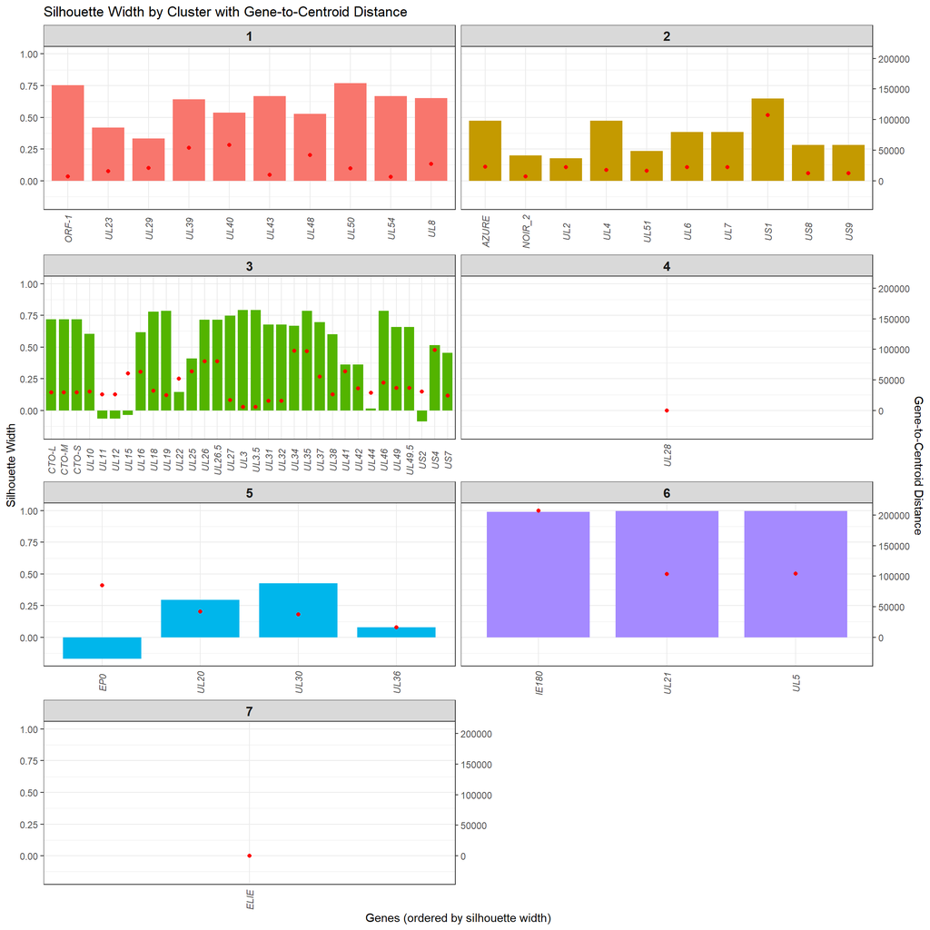

```
## Unclustered Genes, based on a Silhouette threshold of 0 and a Scaled Distance of 20:
## UL15
## UL12
## UL11
## US2
## EP0
```

```
## Unclustered Genes, based on AU threshold of 0.95:
```

#### Clustering statistics: Cluster number: 8

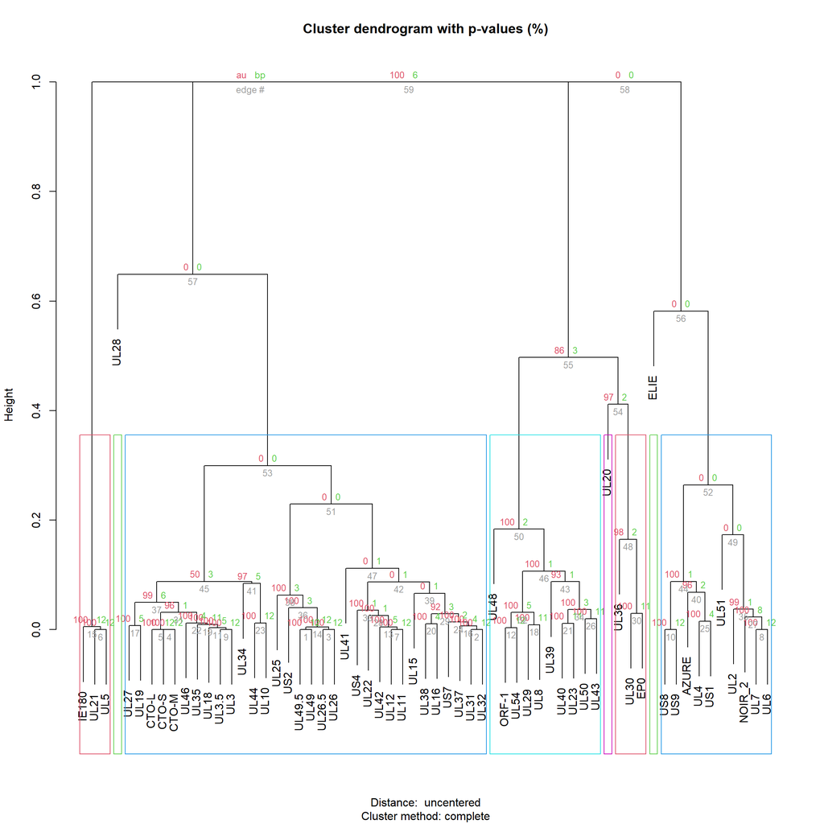

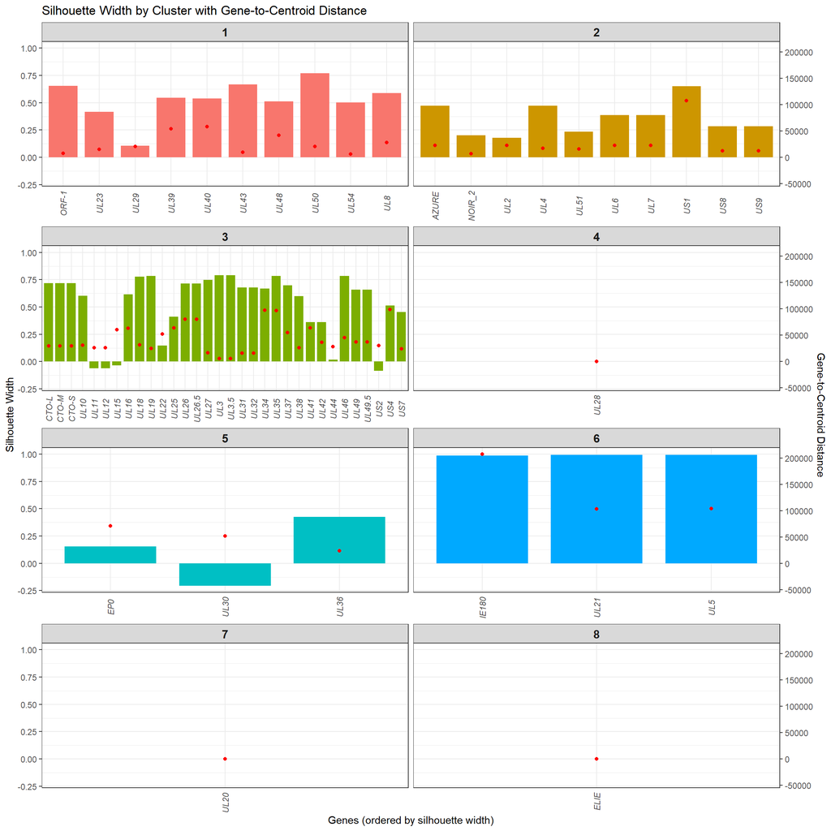

```
## Unclustered Genes, based on a Silhouette threshold of 0 and a Scaled Distance of 20:
## UL15
## UL12
## UL11
## US2
## UL30
```

```
## Unclustered Genes, based on AU threshold of 0.95:
```

#### Clustering statistics: Cluster number: 10

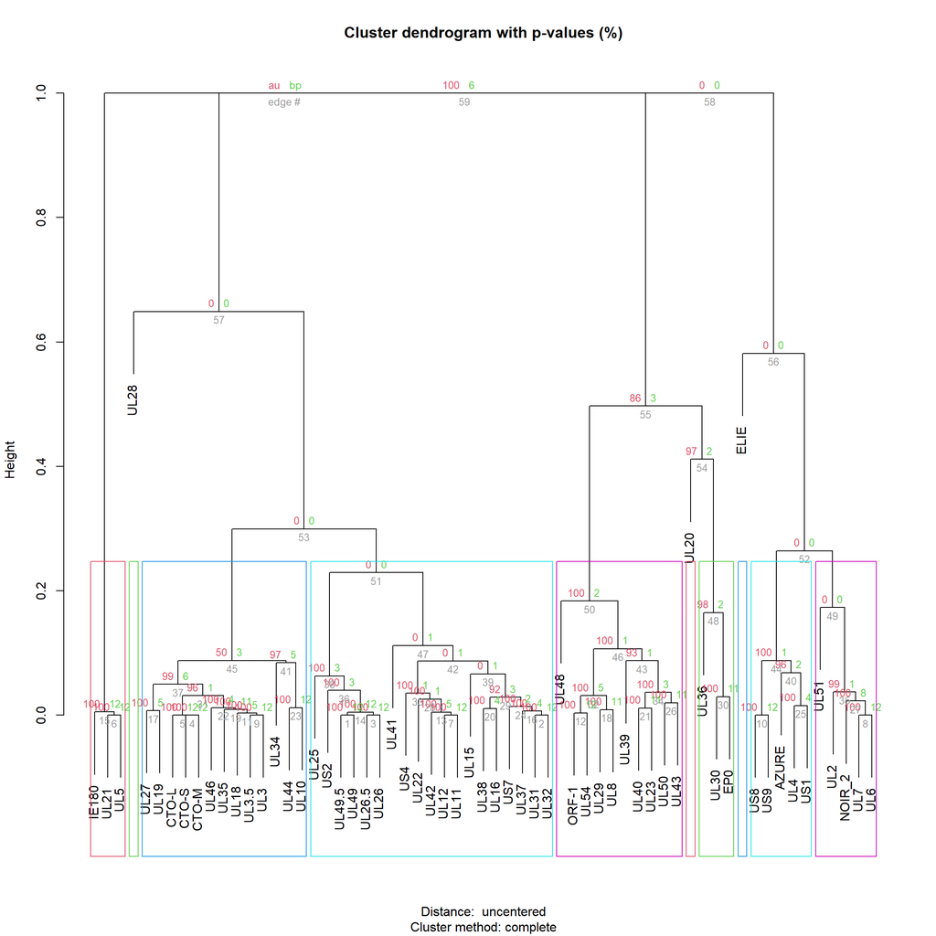

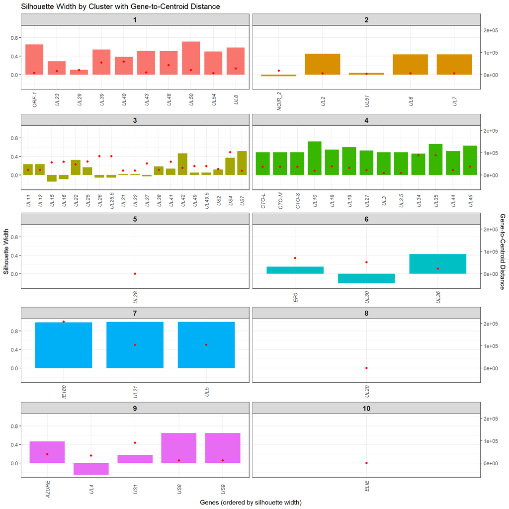

```
## Unclustered Genes, based on a Silhouette threshold of 0 and a Scaled Distance of 20:
## NOIR_2
## UL37
## UL26.5
## UL26
## UL16
## UL15
## UL30
## UL4
```

```
## Unclustered Genes, based on AU threshold of 0.95:
```

#### Clustering statistics: Cluster number: 12

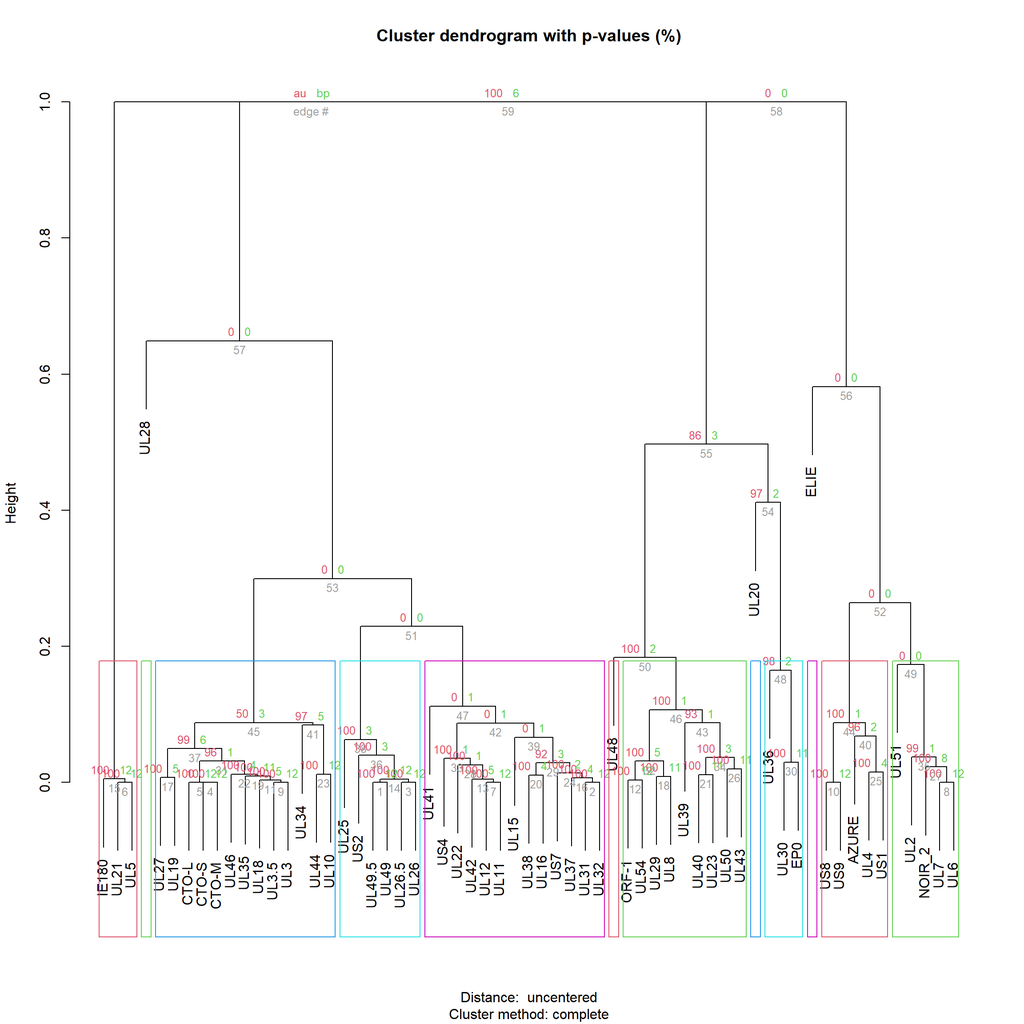

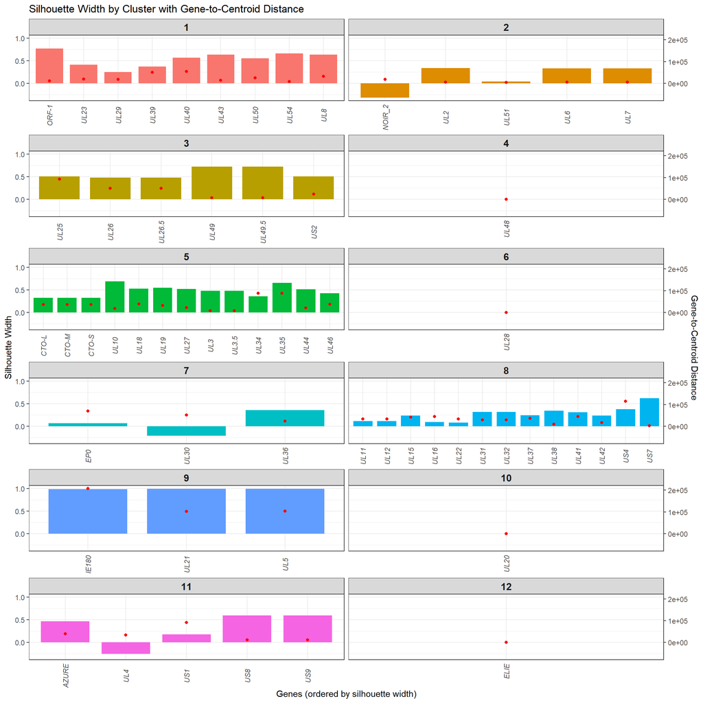

```
## Unclustered Genes, based on a Silhouette threshold of 0 and a Scaled Distance of 20:
## NOIR_2
## UL30
## UL4
```

```
## Unclustered Genes, based on AU threshold of 0.95:
```

### Selected number of clusters: 12

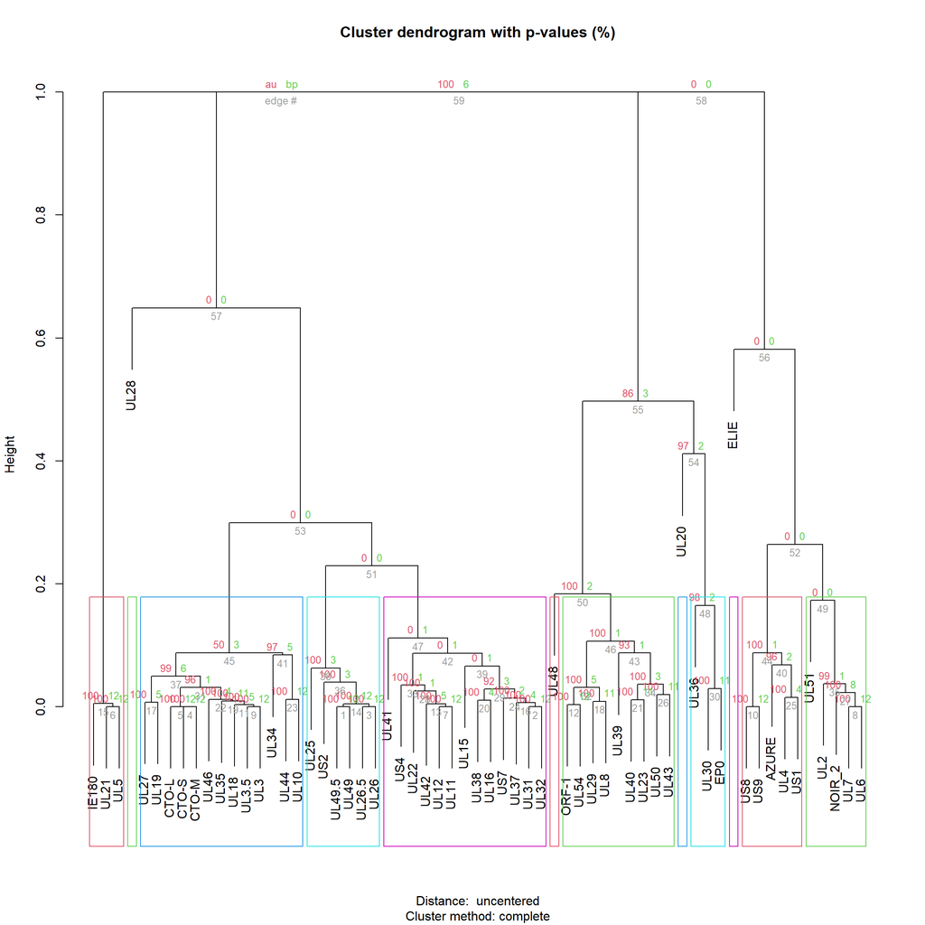

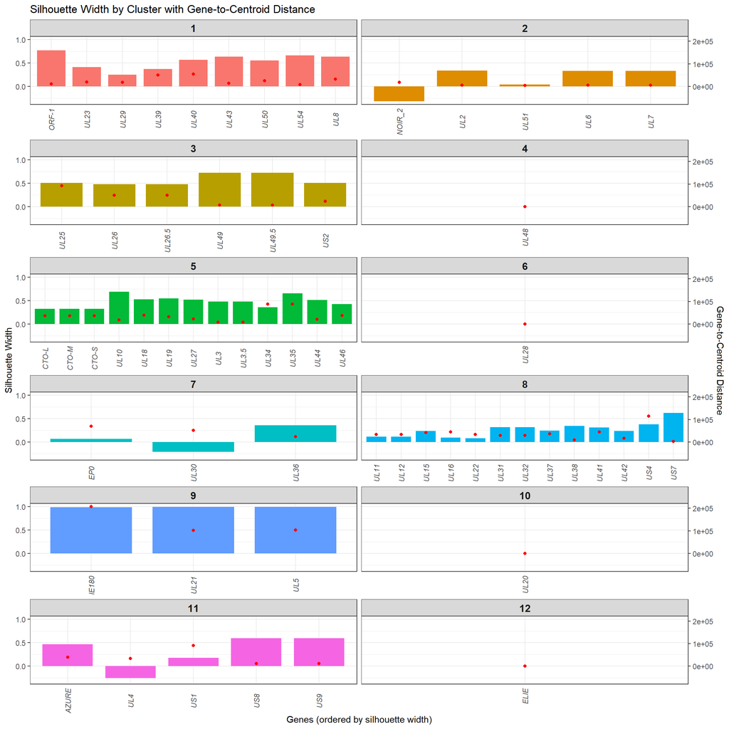

```
## Unclustered Genes, based on a Silhouette threshold of 0 and a Scaled Distance of 20:
## NOIR_2
## UL30
## UL4
```

```
## Unclustered Genes, based on AU threshold of 0.95:
```

### Remove genes from clusters ?

```
## character(0)
```

```
## [1] 0
```

```
## No genes were removed from their corresponding clusters.
```

```
##     cluster     N
##       <int> <int>
##  1:       5    13
##  2:       8    13
##  3:       1     9
##  4:       3     6
##  5:       2     5
##  6:      11     5
##  7:       7     3
##  8:       9     3
##  9:       4     1
## 10:       6     1
## 11:      10     1
## 12:      12     1
```

### Merge cluster stats

### Assigning genes to clusters

### Summarize and melt

## ORF kinetics, according to literature-based kinetic classes

Time-dependent normalized ORF counts (based on TSSs and TES clusters)

### Mean and SD with linear connection

[figure not shown]

### Each replicate with loess

[figure not shown]

### Mean and SD with loess function

## ORF kinetics, according to de-novo kinetic classes

### Figure 5 REVIEW - Mean and SD with linear connection

[figure not shown]

### Mean and SD with linear connection

[figure not shown]

### Each replicate with loess

[figure not shown]

### Mean and SD with loess function

## Combine Classes and Clusters

sum up all the (normalized) gene counts for each kinetic class in each sample (replicate) then take the mean and SD of the sums for each hpi and cell line

### Literature Kinetic Classes

#### Sum and Loess with Confidence

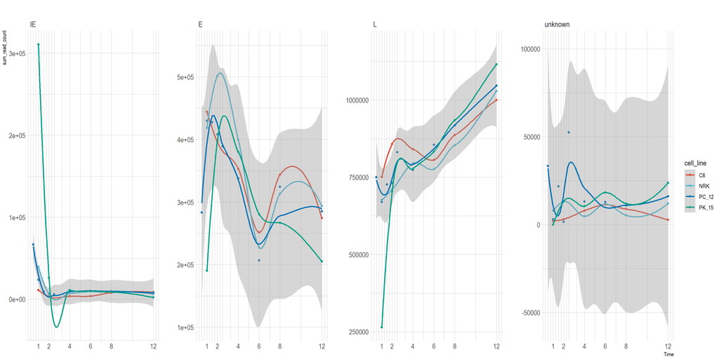

#### Mean and SD with Linear connection

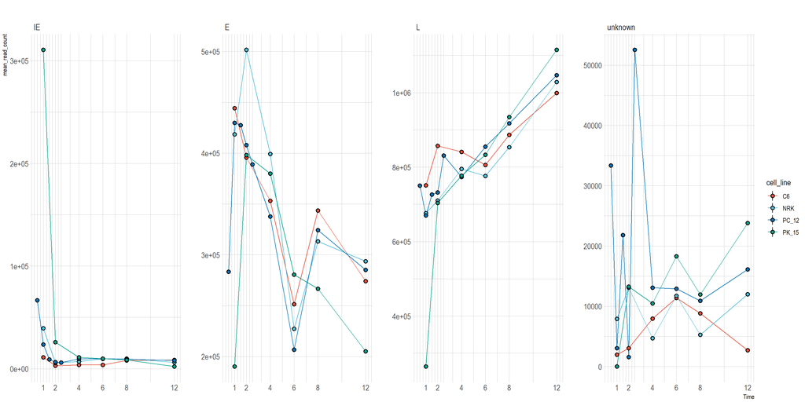

### deNovo clusters

#### Sum and Loess with Confidence

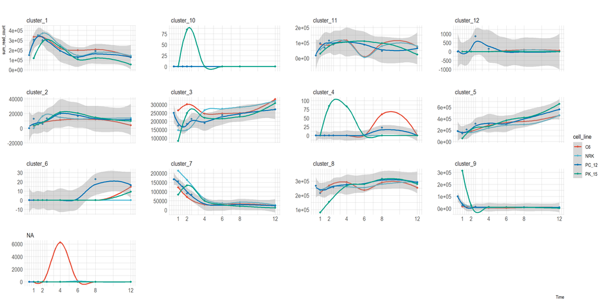

#### Mean and SD with Linear connection

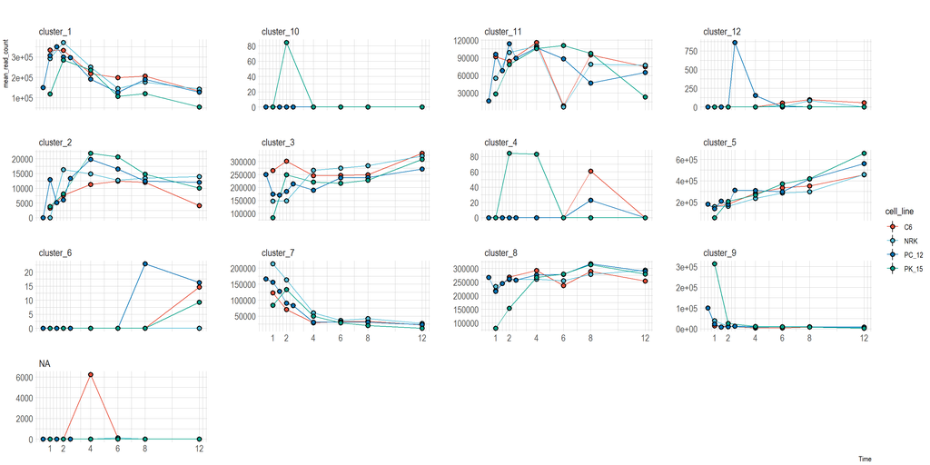

## Compare literature and de novo kinetic classes

*NA shows the number of genes where the clustering did not yield an unambiguous result.*

### each gene 1

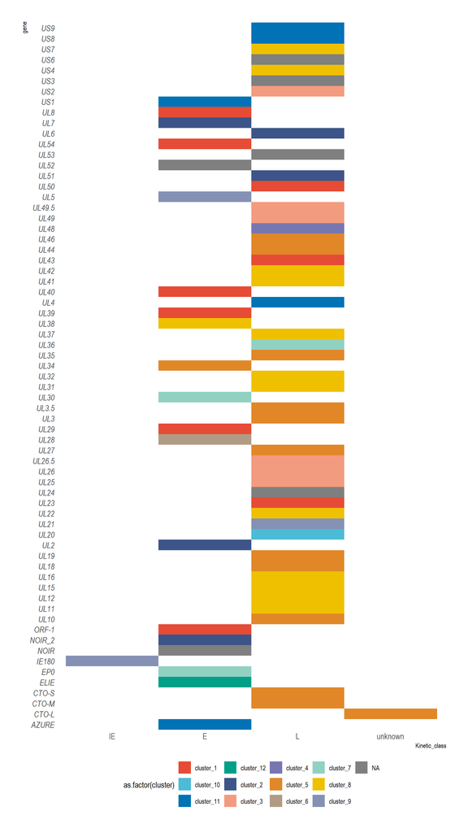

### each gene 2

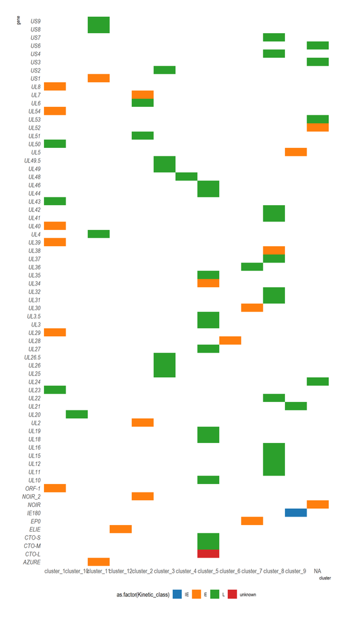

### summary

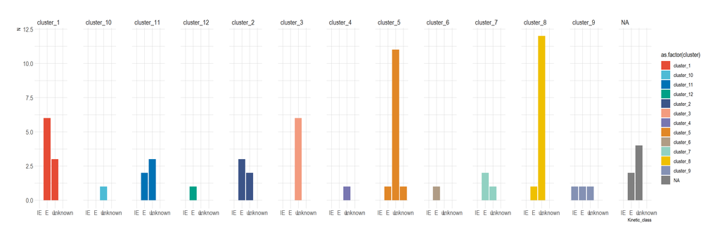

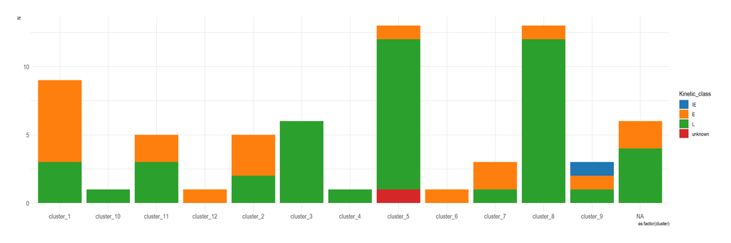

## Literature Clusters and Selected Genes

### Reps with loess and confidence

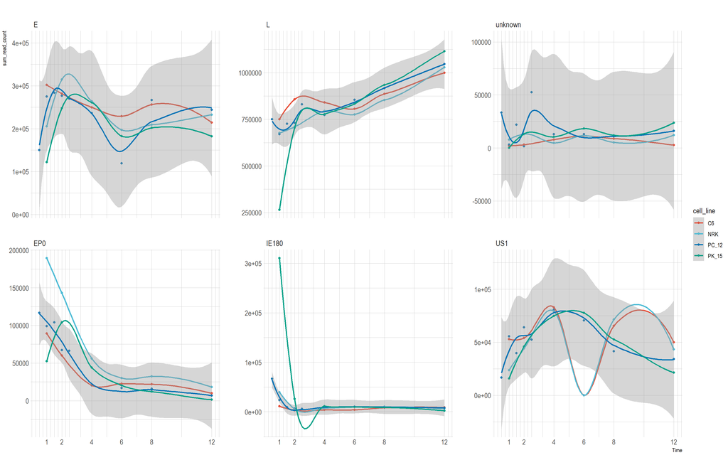

### Means with SD and linear connection

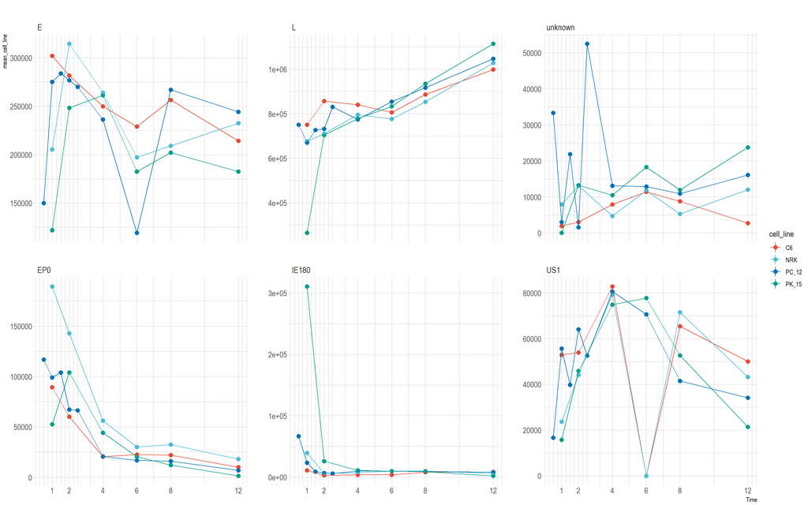

## Gene-pair ratios

### Means with SD and linear connection

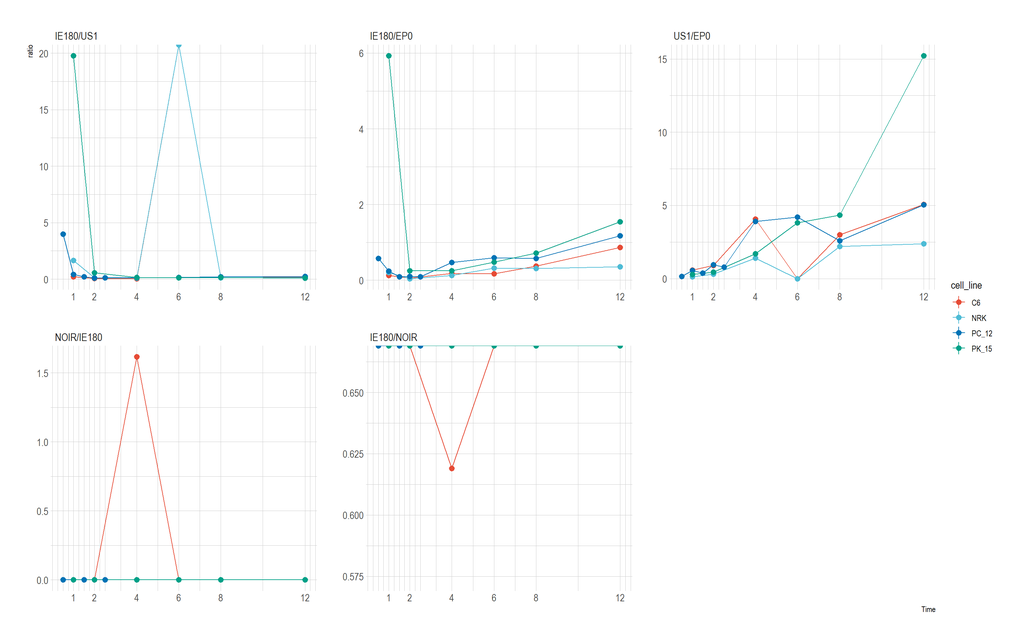

### Reps with loess and confidence

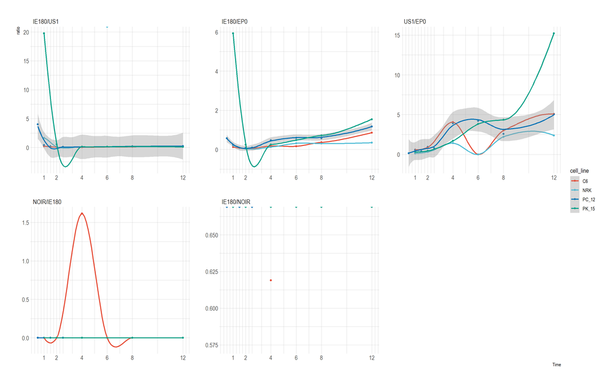

### Sums with linear connection

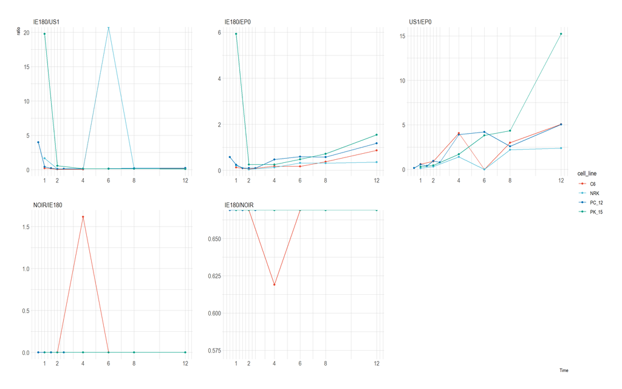